# GEOG728 Final Project Slides

Trevor D. Witt

5/12/2022

## Assignment

### BASE Grant Background

https://www.kansascommerce.gov/basegrant/

### Packages

First up, let’s load all the packages we’ll need for this project.

```r
library(sf)
library(tidyverse)
```

```r
library(ggplot2)
library(readxl)
library(dplyr)
library(PL94171)
library(tmap)
library(ggExtra)
```

### Source Data

This project uses four sources of data. The first is the BASE grant award information. I made my own csv file based on the BASE grant website information.

```r
base_data <- read.csv("BASE_Grant_KS_Data.csv")

base_data <- base_data %>% #Narrow down to County and Award amount.
  select(County, Amount)

base_data <- base_data[-36,] #Remove an empty last row

base_totals <- aggregate(Amount ~ County, base_data, sum) #Sum by county
```

Now we will add our population data. I obtained this data off the census website. What is unique about this data is it is in the .pl format, which is really difficult to work with. This raw type of data is used for redistricting. Fortunately, there is a package built specifically to work with this data **PL94171**. Funny enough, the latest notes for this package were published May 10, 2022, so it is a new an updated package.

This next portion of code shows how to upload this data, and refine it down to where we only have the county name and the total population from 2020.

```r
KS_pop <- pl_read("ks2020.pl")

KS_pop <- pl_subset(KS_pop, sumlev = "050") #050 filters to county level

head(KS_pop) #Data inspection
```

```
## # A tibble: 6 x 397
##   FILEID STUSAB CHARITER LOGRECNO P0010001 P0010002 P0010003 P0010004 P0010005
##   <chr>  <chr>  <chr>       <int>    <int>    <int>    <int>    <int>    <int>
## 1 PLST   KS     000             2    12526    11744    11180      186      150
## 2 PLST   KS     000             3     7836     7506     7312       26       53
## 3 PLST   KS     000             4    16348    15346    14111      788       88
## 4 PLST   KS     000             5     4228     4011     3857        8       34
## 5 PLST   KS     000             6    25493    23556    21157      312      149
## 6 PLST   KS     000             7    14360    13400    12585      469      100
## # ... with 388 more variables: P0010006 <int>, P0010007 <int>, P0010008 <int>,
## #   P0010009 <int>, P0010010 <int>, P0010011 <int>, P0010012 <int>,
## #   P0010013 <int>, P0010014 <int>, P0010015 <int>, P0010016 <int>,
## #   P0010017 <int>, P0010018 <int>, P0010019 <int>, P0010020 <int>,
## #   P0010021 <int>, P0010022 <int>, P0010023 <int>, P0010024 <int>,
## #   P0010025 <int>, P0010026 <int>, P0010027 <int>, P0010028 <int>,
## #   P0010029 <int>, P0010030 <int>, P0010031 <int>, P0010032 <int>, ...
```

```r
tail(KS_pop)
```

```
## # A tibble: 6 x 397
##   FILEID STUSAB CHARITER LOGRECNO P0010001 P0010002 P0010003 P0010004 P0010005
##   <chr>  <chr>  <chr>       <int>    <int>    <int>    <int>    <int>    <int>
## 1 PLST   KS     000           101     1512     1426     1370        3        5
## 2 PLST   KS     000           102     5530     5288     5153       13        5
## 3 PLST   KS     000           103     2152     1850     1547        3       23
## 4 PLST   KS     000           104     8624     7994     7759       22       88
## 5 PLST   KS     000           105     3115     2945     2890        8       30
## 6 PLST   KS     000           106   169245   143962    73721    34589     1917
## # ... with 388 more variables: P0010006 <int>, P0010007 <int>, P0010008 <int>,
## #   P0010009 <int>, P0010010 <int>, P0010011 <int>, P0010012 <int>,
## #   P0010013 <int>, P0010014 <int>, P0010015 <int>, P0010016 <int>,
## #   P0010017 <int>, P0010018 <int>, P0010019 <int>, P0010020 <int>,
## #   P0010021 <int>, P0010022 <int>, P0010023 <int>, P0010024 <int>,
## #   P0010025 <int>, P0010026 <int>, P0010027 <int>, P0010028 <int>,
## #   P0010029 <int>, P0010030 <int>, P0010031 <int>, P0010032 <int>, ...
```

```r
KS_pop[,"BASENAME"]
```

```
## # A tibble: 105 x 1
##    BASENAME
##    <chr>
##  1 Allen
##  2 Anderson
##  3 Atchison
##  4 Barber
##  5 Barton
##  6 Bourbon
##  7 Brown
##  8 Butler
##  9 Chase
## 10 Chautauqua
## # ... with 95 more rows
```

```r
KS_pop[,"POP100"] #Filter to these two
```

```
## # A tibble: 105 x 1
##    POP100
##     <int>
##  1  12526
##  2   7836
##  3  16348
##  4   4228
##  5  25493
##  6  14360
##  7   9508
##  8  67380
##  9   2572
## 10   3379
## # ... with 95 more rows
```

```r
names(KS_pop)
```

[output not shown]

[output cut: 52 more lines]

```r
KS_pop <- KS_pop %>%
  select(BASENAME, POP100)
```

Next we will add our GDP data, which comes from the Buraeu of Economic Analysis. We will perform similar operations to get us to just the County and GDP data for 2020.

```r
KS_gdp <- read.csv("CAGDP1_KS_2001_2020.csv")

colnames(KS_gdp)
```

```
##  [1] "GeoFIPS"                "GeoName"                "Region"
##  [4] "TableName"              "LineCode"               "IndustryClassification"
##  [7] "Description"            "Unit"                   "X2001"
## [10] "X2002"                  "X2003"                  "X2004"
## [13] "X2005"                  "X2006"                  "X2007"
## [16] "X2008"                  "X2009"                  "X2010"
## [19] "X2011"                  "X2012"                  "X2013"
## [22] "X2014"                  "X2015"                  "X2016"
## [25] "X2017"                  "X2018"                  "X2019"
## [28] "X2020"
```

```r
KS_gdp_2020 <- KS_gdp[-c(1:3),-c(1,3,4,6,9:27)] #Remove data I don't need

KS_gdp_2020 <- filter(KS_gdp_2020, LineCode == 3)

KS_gdp_2020 <- KS_gdp_2020[-c(2:4)]
```

Last, we need to load the shape file for the Kansas counties.

```r
KS_counties <- st_read("KS_counties.shp")
KS_counties <- KS_counties[-c(1:5,7:14)] #Reduce to data I need
```

### Consistent Data Format & Naming

Now I need to make sure all the column names are the same so we can merge them together without issues.

```r
#Shape file
names(KS_counties)[names(KS_counties) == "name"] <- "County"

#GDP
names(KS_gdp_2020)[names(KS_gdp_2020) == "GeoName"] <- "County"
names(KS_gdp_2020)[names(KS_gdp_2020) == "X2020"] <- "GDP"

KS_gdp_2020 <- KS_gdp_2020 %>%
  mutate_at("County", str_replace, ", KS", "") #Remove a suffix I don't need

#Population
names(KS_pop)[names(KS_pop) == "BASENAME"] <- "County"
names(KS_pop)[names(KS_pop) == "POP100"] <- "Population"
```

We also need to make sure each data set is the same type, and let’s inspect our work so far.

```r
tibble::as_tibble(base_totals)
```

```
## # A tibble: 24 x 2
##    County     Amount
##    <chr>       <int>
##  1 Allen     2905095
##  2 Atchison    13500
##  3 Barton    3000000
##  4 Butler   15500000
##  5 Doniphan   226000
##  6 Douglas   5000000
##  7 Ellis     2623300
##  8 Franklin  5000000
##  9 Graham     290178
## 10 Harper    3000000
## # ... with 14 more rows
```

```r
tibble::as_tibble(KS_gdp_2020)
```

```
## # A tibble: 105 x 2
##    County         GDP
##    <chr>        <dbl>
##  1 Allen       607820
##  2 Anderson    290651
##  3 Atchison    727287
##  4 Barber      186697
##  5 Barton     1235615
##  6 Bourbon     633432
##  7 Brown       545290
##  8 Butler     2566780
##  9 Chase       126006
## 10 Chautauqua   82164
## # ... with 95 more rows
```

```r
tibble::as_tibble(KS_pop)
```

```
## # A tibble: 105 x 2
##    County     Population
##    <chr>           <int>
##  1 Allen           12526
##  2 Anderson         7836
##  3 Atchison        16348
##  4 Barber           4228
##  5 Barton          25493
##  6 Bourbon         14360
##  7 Brown            9508
##  8 Butler          67380
##  9 Chase            2572
## 10 Chautauqua       3379
## # ... with 95 more rows
```

Looks good!

### Merge Data

Now I will merge all this data into one table to work with.

```r
award_gdp <- dplyr::left_join(KS_gdp_2020, base_totals, by = "County")

all_data <- dplyr::left_join(award_gdp, KS_pop, by = "County")
```

There are NAs for the counties that did not recieve grants, so let’s changes those NA’s to zeros.

```r
all_data[is.na(all_data)] <- 0

all_data #This has BASE award amount, GPD, and Population all by county and all by 2020 numbers.
```

```
##           County      GDP   Amount Population
## 1          Allen   607820  2905095      12526
## 2       Anderson   290651        0       7836
## 3       Atchison   727287    13500      16348
## 4         Barber   186697        0       4228
## 5         Barton  1235615  3000000      25493
## 6        Bourbon   633432        0      14360
## 7          Brown   545290        0       9508
## 8         Butler  2566780 15500000      67380
## 9          Chase   126006        0       2572
## 10    Chautauqua    82164        0       3379
## 11      Cherokee   810962        0      19362
## 12      Cheyenne   124036        0       2616
## 13         Clark   185287        0       1991
## 14          Clay   300236        0       8117
```

[output cut: 91 more lines]

### Bar Plots

First, lets visualize this data using bar graphs.

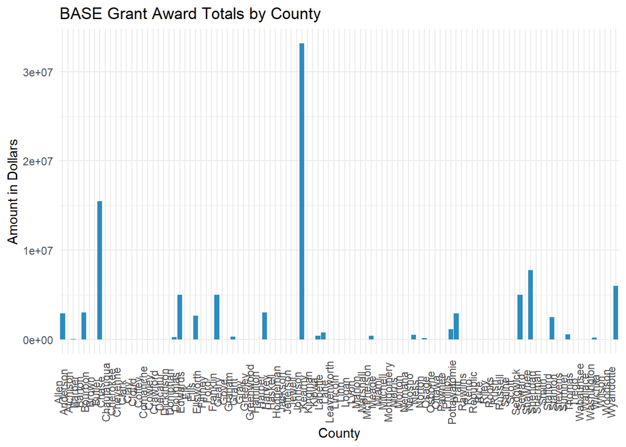

```r
all_data %>%
  ggplot(.) +
    geom_bar(aes(x = County, y = Amount), stat = "identity", fill = "#2b8cbe") +
    theme_minimal() +
    theme(axis.text.x = element_text(angle = 90, vjust = -0.1)) +
    ggtitle("BASE Grant Award Totals by County") + ylab("Amount in Dollars")
```

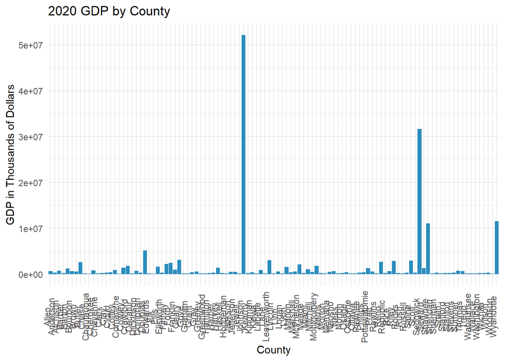

```r
all_data %>%
  ggplot(.) +
  geom_bar(aes(x = County, y = GDP), stat = "identity", fill = "#2b8cbe") +
  theme_minimal() +
  theme(axis.text.x = element_text(angle = 90, vjust = -0.1)) +
  ggtitle("2020 GDP by County") + ylab("GDP in Thousands of Dollars")
```

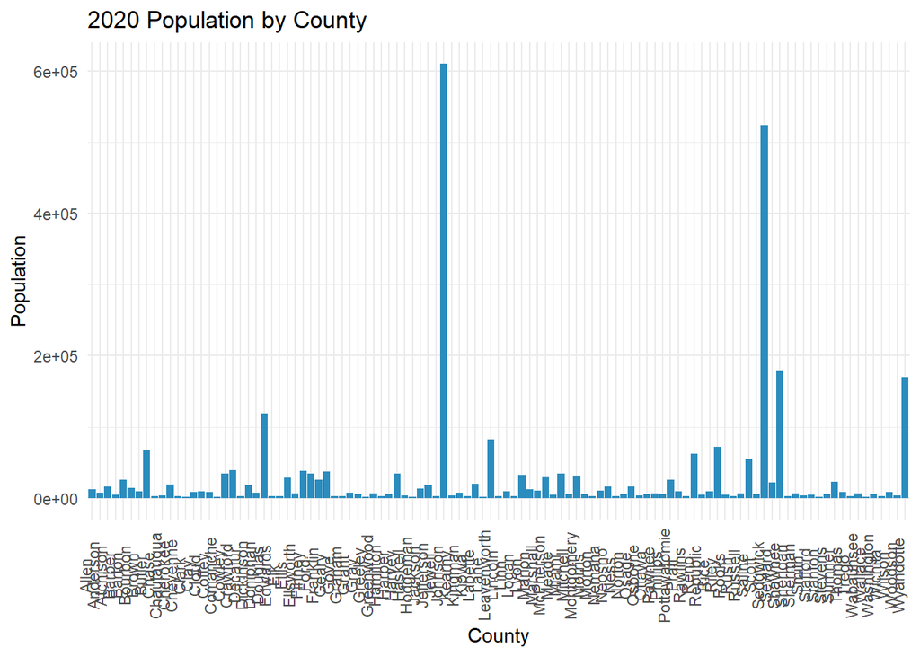

```r
all_data %>%
  ggplot(.) +
  geom_bar(aes(x = County, y = Population), stat = "identity",
           fill = "#2b8cbe") +
  theme_minimal() +
  theme(axis.text.x = element_text(angle = 90, vjust = -0.1)) +
  ggtitle("2020 Population by County") + ylab("Population")
```

The major outliers are pretty visible, but it’s difficult to see exactly what all else is going on.

### Ggplot Maps

Let’s now plot out these values on a Kansas map of counties.

First we need to join our data with the Kansas counties shape file.

```r
mapped_data <- left_join(KS_counties, all_data, by = "County")

head(mapped_data)
```

```
## Simple feature collection with 6 features and 4 fields
## Geometry type: POLYGON
## Dimension:     XY
## Bounding box:  xmin: -102.0446 ymin: 37.47042 xmax: -97.37175 ymax: 38.60988
## Geodetic CRS:  WGS 84
##      County     GDP Amount Population                       geometry
## 1  Hamilton  232356      0       2518 POLYGON ((-102.0446 38.2624...
## 2 McPherson 2096816 409914      30223 POLYGON ((-97.92479 38.6098...
## 3      Gray  529997      0       5653 POLYGON ((-100.6642 38.0025...
## 4     Pratt  577840      0       9157 POLYGON ((-99.01332 37.8253...
## 5      Reno 2664365      0      61898 POLYGON ((-98.47279 38.1727...
## 6      Rice  592062      0       9427 POLYGON ((-98.48038 38.5218...
```

Now let’s look at those maps.

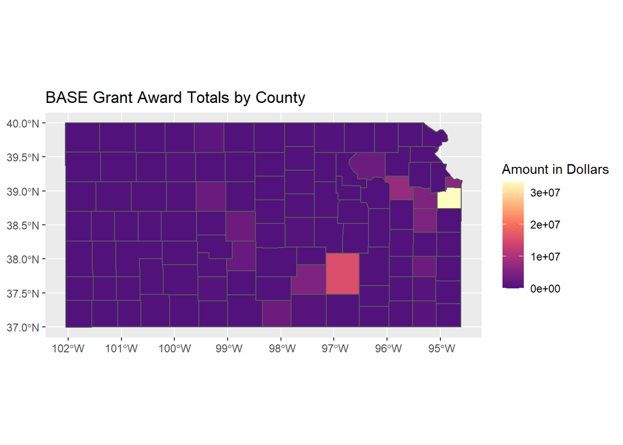

```r
ggplot() +
  geom_sf(data = mapped_data, aes(fill = Amount))+
  labs(fill = "Amount in Dollars") +
  ggtitle("BASE Grant Award Totals by County")+
  scale_fill_viridis_c(option="magma", begin=0.25)
```

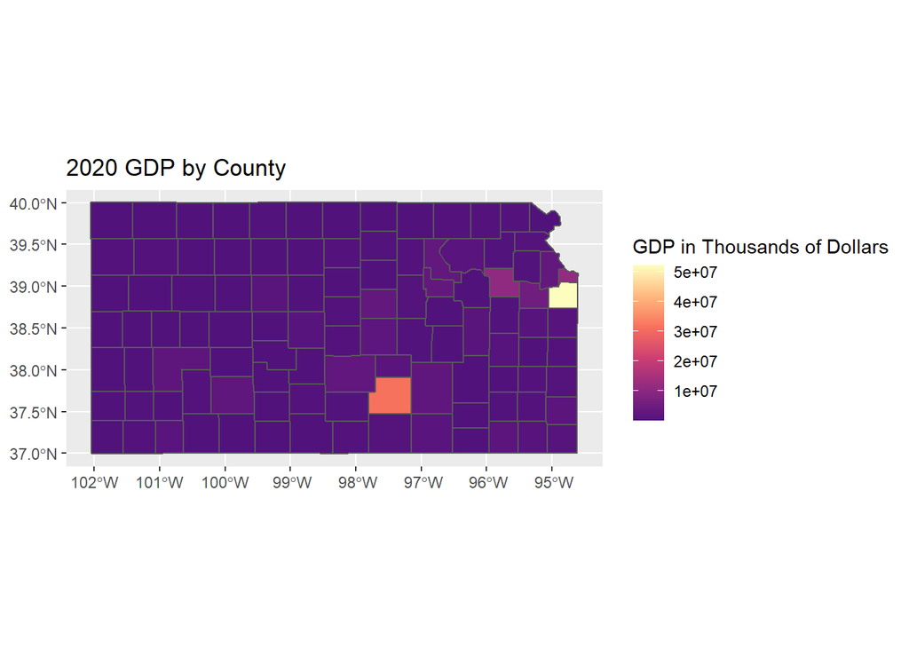

```r
ggplot() +
  geom_sf(data = mapped_data, aes(fill = GDP))+
  labs(fill = "GDP in Thousands of Dollars") +
  ggtitle("2020 GDP by County")+
  scale_fill_viridis_c(option="magma", begin=0.25)
```

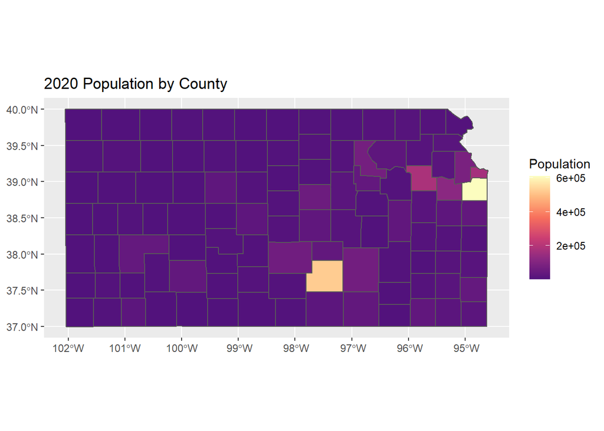

```r
ggplot() +
  geom_sf(data = mapped_data, aes(fill = Population))+
  ggtitle("2020 Population by County")+
  scale_fill_viridis_c(option="magma", begin=0.25)
```

We are seeing some better detail on the differences now. However, it would be nice to “stack” some of this data on top of each other.

### Tmap Interactive

By using the **tmap** package, we can better see these varaibles along side each other. Also, by using the view mode, we can more intuitively interact with these maps.

```r
tmap_mode("view")
```

```
## tmap mode set to interactive viewing
```

```r
tm_shape(mapped_data) +
  tm_polygons("Amount") +
  tm_bubbles("GDP", col="green")
```

```
## Legend for symbol sizes not available in view mode.
```

[interactive chart not shown]

```r
tm_shape(mapped_data) +
  tm_polygons("Amount") +
  tm_bubbles("Population", col="blue")
```

```
## Legend for symbol sizes not available in view mode.
```

[interactive chart not shown]

As a result, it does look like the award direction was pretty fair based on the populations and GDP of each county. If any county was shorted, it is likely Sedgwick not getting enough, but Butler county received an excess.

Butler County does border Sedgwick County, but I do find it interesting that Butler would receive an excess of BASE grant awards, given the Kansas Senate President represents Butler.

### Regression

[figure not shown]

```r
base_pop <- ggplot(data = mapped_data, aes(x = mapped_data$Population, y = mapped_data$Amount)) +
  geom_point() +
  theme(legend.position = "none") +
  xlab("Population") +
  ylab("Award Amount in Dollars")

ggMarginal(base_pop, type = "histogram")
base_gdp <- ggplot(data = mapped_data, aes(x = mapped_data$GDP, y = mapped_data$Amount)) +
  geom_point() +
  theme(legend.position = "none") +
  xlab("Population") +
  ylab("GDP in Thousands of Dollars")

ggMarginal(base_gdp, type = "histogram")
```

[output not shown]

There is obviously some wide gaps here. I wish I could have mapped out more, but that’s all the time I have.

This has been a great class!

### Sources

GDP https://apps.bea.gov/regional/downloadzip.cfm

Census Data https://www.census.gov/programs-surveys/decennial-census/about/rdo/summary-files.html

KS Counties File from class

BASE Grants https://www.kansascommerce.gov/basegrant/